# Chromosome compaction - simple three-state model

```r
library(mylib)
library(ChromCom)
library(ggplot2)
library(gridExtra)
library(reshape2)
library(parallel)
binDir <- "../RData"
```

# 11/07/2017

Writing introduction. First script to do simulation.

# 12/07/2017

Let’s try if it works. An example for $t_1 = -60$ min, $\Delta t = 0$, $k_1 = 0.04\ {\rm min}^{-1}$ and $k_2 = 0.04\ {\rm min}^{-1}$.

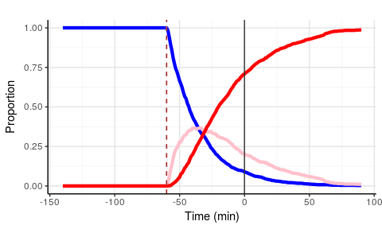

```r
pars <- c3pars(
  t1 = -60,
  dt2 = 0,
  k1 = 0.04,
  k2 = 0.04
)
chr <- ChromCom3(pars)
chr <- generateCells(chr, nsim=1000)
plotTimelines(chr)
```

Just to check if output is as expected. With $k_2=0$ we should have pure exponential decay. The yellow curve is $e^{-k_1 t}$.

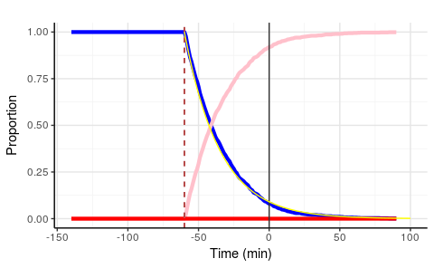

```r
pars <- c3pars(
  t1 = -60,
  dt2 = 0,
  k1 = 0.04,
  k2 = 0
)
tchr <- ChromCom3(pars)
tchr <- generateCells(tchr, nsim=1000)
x <- seq(from=pars$t1, to=100, by=1)
y <- exp(-pars$k1 * (x - pars$t1))
g <- plotTimelines(tchr)
g + geom_line(data=data.frame(x=x, y=y), aes(x,y), colour="yellow")
```

Close, but not perfect. Here is an example with much smaller time step (0.1) and larger number of cells (10,000).

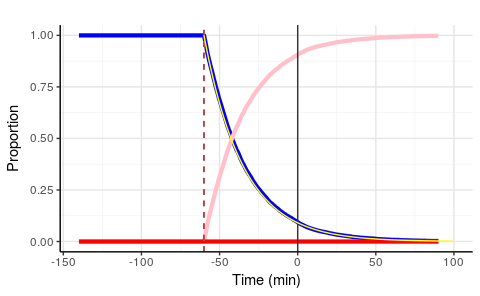

```r
pars <- c3pars(
  t1 = -60,
  dt2 = 0,
  k1 = 0.04,
  k2 = 0
)
tchr <- ChromCom3(pars, time = seq(from=-140, to=90, by=0.1))
tchr <- generateCells(tchr, nsim=10000)
x <- seq(from=pars$t1, to=100, by=1)
y <- exp(-pars$k1 * (x - pars$t1))
g <- plotTimelines(tchr)
g + geom_line(data=data.frame(x=x, y=y), aes(x,y), colour="yellow")
```

## Parameter grid

```r
parameterGrid <- function(pars, par1, range1, par2, range2) {
  melts <- NULL
  for(p1 in range1) {
    pars[[par1]] <- p1
    for(p2 in range2) {
      pars[[par2]] <- p2
      chr <- ChromCom3(pars)
      chr <- generateCells(chr)
      label1 <- sprintf("%s = %.3g", par1, p1)
      label2 <- sprintf("%s = %.3g", par2, p2)
      m <- meltTimelines(chr, label1=label1, label2=label2)
      melts <- rbind(melts, m)
    }
  }
  timelinePanel(melts)
}
```

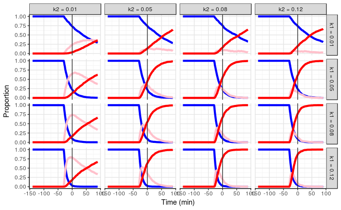

```r
pars <- c3pars(
  t1 = -30,
  dt2 = 0,
  k1 = 0.05,
  k2 = 0.01
)
range1 <- c(0.01, 0.05, 0.08, 0.12)
range2 <- c(0.01, 0.05, 0.08, 0.12)
parameterGrid(pars, "k1", range1, "k2", range2)
```

I think we need to introduce a delay between pink and red.

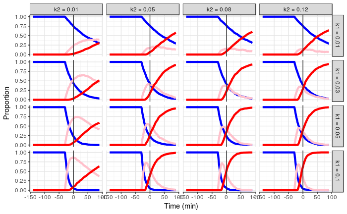

```r
pars <- c3pars(
  t1 = -30,
  dt2 = 10,
  k1 = 0.05,
  k2 = 0.01
)
range1 <- c(0.01, 0.03, 0.05, 0.10)
range2 <- c(0.01, 0.05, 0.08, 0.12)
parameterGrid(pars, "k1", range1, "k2", range2)
```

What about range of delays?

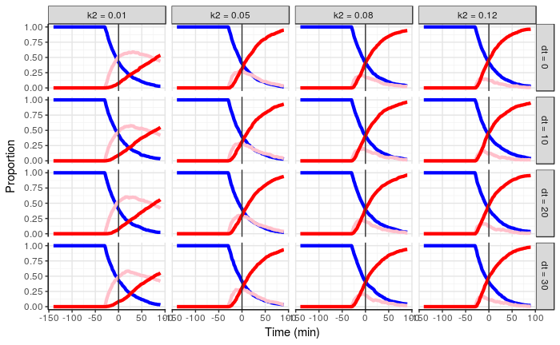

```r
pars <- c3pars(
  t1 = -30,
  dt2 = 0,
  k1 = 0.03,
  k2 = 0.01
)
range1 <- c(0, 10, 20, 30)
range2 <- c(0.01, 0.05, 0.08, 0.12)
parameterGrid(pars, "dt", range1, "k2", range2)
```

Experimental data.

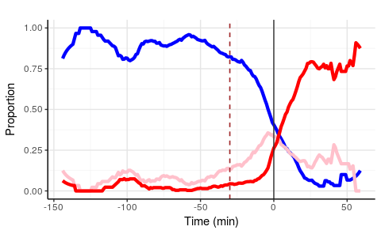

```r
echr.scr <- experimentalData(dataFile$scramble)
echr.d2 <- experimentalData(dataFile$NCAPD2)
echr.d3 <- experimentalData(dataFile$NCAPD3)
echr.smc <- experimentalData(dataFile$SMC2)
plotTimelines(echr.scr, smooth=TRUE, k=15)
```

# 13/07/2017

Prepared [shiny app](https://shiny.compbio.dundee.ac.uk/marek_chromcom/param_tuner/) for deployment.

# 24/07/2017

Tomo suggested that the model parameters can be derived directly from data. We can write the following equations

$\dot{B} = -k_1 B$

$\dot{R} = k_2 P$

$B + P + R = 1$

However, I’m not sure if this is exactly the model I use in the simulation. In the simulation, we assumed that P->R transition can happen only after the B->P transition.

Because proportions and their derivatives are observed, we can find the rates:

$k_1 = - \frac{\dot{B}}{B}$

$k_2 = \frac{\dot{R}}{P}$

This will require a lot of smoothing, otherwise the derivatives will be all over the place.

First, I see if I can recover rates from the generated data.

```r
timeDeriv <- function(chr, k=20) {
  ts <- list()
  for(col in chr$colours) {
    x <- chr$cnt[[col]] / chr$cnt$total
    x <- caTools::runmean(x, k)
    x <- ts(x, start=chr$timepars$start, deltat=chr$timepars$step)
    xdot <- diff(x)
    ts[[col]] <- x
    ts[[paste0(col, ".diff")]] <- xdot
  }
  ts
}
```

```r
plotRates <- function(chr, k=20) {
  ts <- timeDeriv(chr, k=k)
  k1 <- -ts$B.diff / ts$B
  k2 <- ts$R.diff / ts$P
  k1[which(is.nan(k1))] <- NA
  k2[which(is.nan(k2))] <- NA
  df <- data.frame(t=time(k1), k1=k1, k2=k2)
  m <- melt(df, measure.vars = c("k1", "k2"))
  m$value <- as.numeric(m$value)
  m$value[which(m$value > 0.5)] <- 0.5
  m$value[which(m$value < -0.5)] <- -0.5
  ggplot(m, aes(x=t, y=value)) + geom_line(aes(colour=variable))
}
```

Start with a model with 10,000 cells and 0.1 min time step. In this model $k_1 = 0.04$ and $k_2 = 0$. Top panels show original data, lower panels - smoothed data.

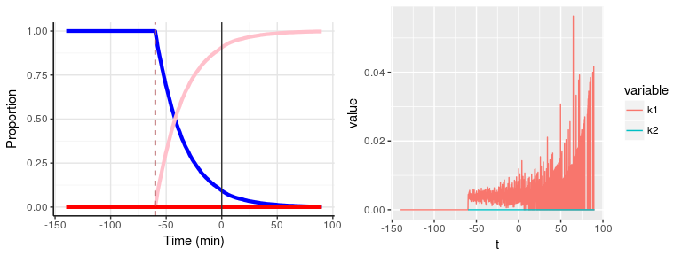

```r
grid.arrange(plotTimelines(tchr), plotRates(tchr, k=1), ncol=2)
```

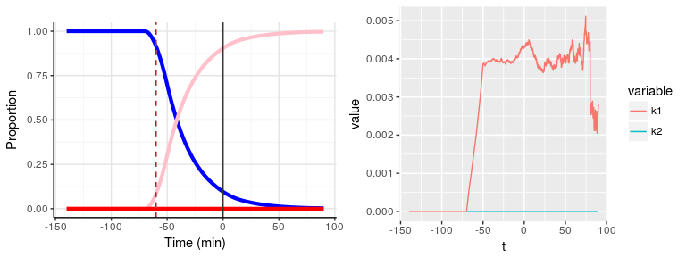

```r
grid.arrange(plotTimelines(tchr, smooth=TRUE, k=200), plotRates(tchr, k=200), ncol=2)
```

What happens if I use only 100 cells and 1 min time step in the model? This time $k_2 = 0.04$.

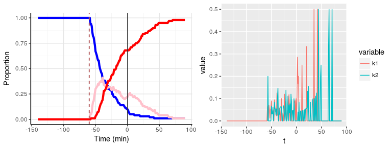

```r
chr <- generateCells(chr, nsim=100)
grid.arrange(plotTimelines(chr, k=1), plotRates(chr, k=1), ncol=2)
```

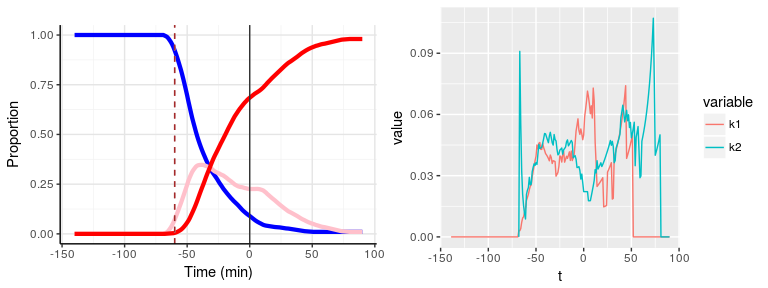

```r
grid.arrange(plotTimelines(chr, smooth=TRUE, k=20), plotRates(chr, k=20), ncol=2)
```

And now, for real data. Here are scramble data smoothed with running mean with window size of 10 time points.

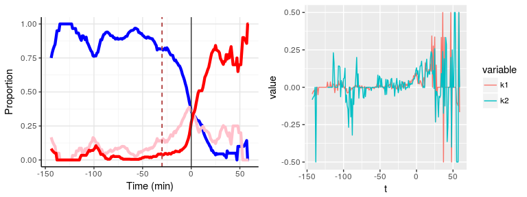

```r
grid.arrange(plotTimelines(echr.scr, smooth=TRUE, k=10), plotRates(echr.scr, k=10), ncol=2)
```

Now, smoothing with 80 points.

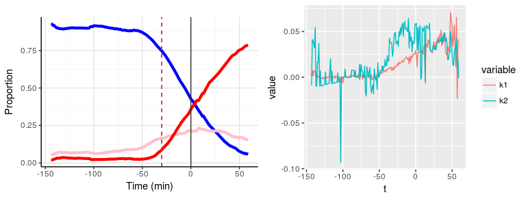

```r
grid.arrange(plotTimelines(echr.scr, smooth=TRUE, k=80), plotRates(echr.scr, k=80), ncol=2)
```

# 25/07/2017

Had a chat with Tomo and John yesterday. They wanted to add a score showing how far the model is from the experimental data. I did it by calculating $\chi^2$ summed over all three curves. It is now added to the figure in the shiny app.

The next thing is to add transition P->B, with rate $k_3$. It can happen only after time $\Delta t_3$.

I added a simulation method (step-by-step). Now testing it.

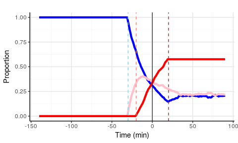

```r
pars <- c3pars(
  t1 = -30,
  k1 = 0.04,
  k2 = 0.04,
  k3 = 0.04,
  dt2 = 10,
  dt3 = 50
)
chr <- ChromCom3(pars)
chr <- generateCells(chr, nsim=1000, method="simulation")
plotTimelines(chr)
```

# 26/07/2017

What about fitting model to the data? “nlm” doesn’t work because model is stochastic. Method “SANN” from optim (that is stochastic simulated annealing) took very long time and went into a false minimum (negative $k_2$), as parameters cannot be constrained.

Finally I used “L-BFGS-B” method which allows box constraints. Alas, this method is not very good at finding the real minimum, often ending up in a local one. I’m guessing this is because of my stochastic model. Therefore, I need to run it several times and search for the best minimum. Using “mclapply” to speed it up.

I also changed the error score. $\chi^2$ doesn’t work very well when expected counts are zero. And I cannot simply exclude them, because zero is an important number. Instead I calculate a simple RMS.

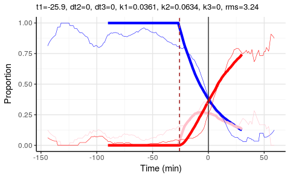

```r
pars <- c3pars()
chr <- cacheData("fit_scramble_n3000_3par", fitChr, echr.scr, pars, npar=3, nsim=3000, ntry=16, binDir=binDir)
plotTimelines(chr, expdata = echr.scr, withpars=TRUE)
```

Now, the same, but with extra parameter, $\Delta t_2$.

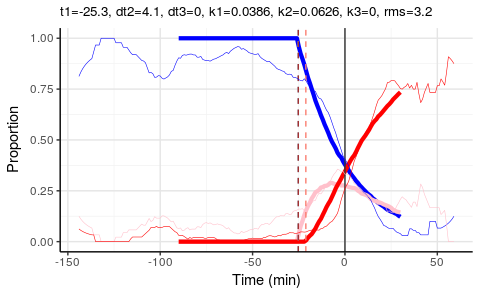

```r
pars <- c3pars(dt2=5)
chr <- cacheData("fit_scramble_n3000_4par", fitChr, echr.scr, pars, npar=4, nsim=3000, ntry=16, binDir=binDir)
plotTimelines(chr, expdata = echr.scr, withpars=TRUE)
```

And now the other two data sets.

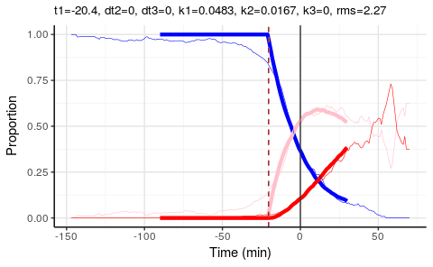

```r
pars <- c3pars()
chr2 <- cacheData("fit_NCAPD2_n3000_3par", fitChr, echr.d2, pars, npar=3, nsim=3000, ntry=16, ncores=8, binDir=binDir)
plotTimelines(chr2, expdata = echr.d2, withpars=TRUE)
```

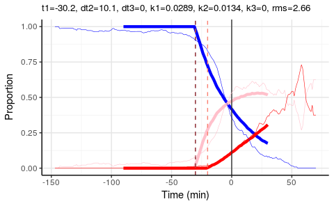

```r
pars <- c3pars(dt2=10)
chr2 <- cacheData("fit_NCAPD2_n3000_4par", fitChr, echr.d2, pars, npar=4, nsim=3000, ntry=16, ncores=8, binDir=binDir)
plotTimelines(chr2, expdata = echr.d2, withpars=TRUE)
```

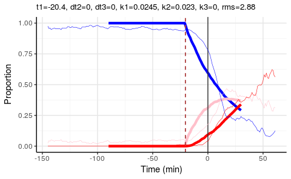

```r
echr.d3 <- experimentalData(dataFile$NCAPD3)
pars <- c3pars()
chr3 <- cacheData("fit_NCAPD3_n3000_3par", fitChr, echr.d3, pars, npar=3, nsim=3000, ntry=16, ncores=8, binDir=binDir)
plotTimelines(chr3, expdata = echr.d3, withpars=TRUE)
```

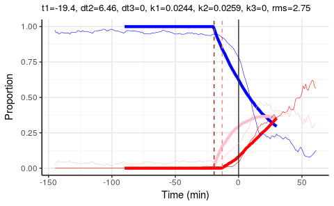

```r
pars <- c3pars(dt2=10)
chr3 <- cacheData("fit_NCAPD3_n3000_4par", fitChr, echr.d3, pars, npar=4, nsim=3000, ntry=16, ncores=8, binDir=binDir)
plotTimelines(chr3, expdata = echr.d3, withpars=TRUE)
```

# 02/08/2017

Discussed new approach to fitting with John. The plan is as follows.

- fit scramble with $t_1$, $k_1$ and $k_2$ free
- for NCAPD2 we expect only $k_2$ to change, so fix $k_1$ from scramble
- for NCAPD3 we expect only $k_1$ to change, so fix $k_2$ from scramble; however, John tried this manually and it didn’t work very well, so we might free both ks
- for SMC2 $k_1$ fixed from NCAPD3, $k_2$ fixed from NCAPD2 and see if this matches; then do a fit
- lets keep all $\Delta t$ fixed

## Scramble

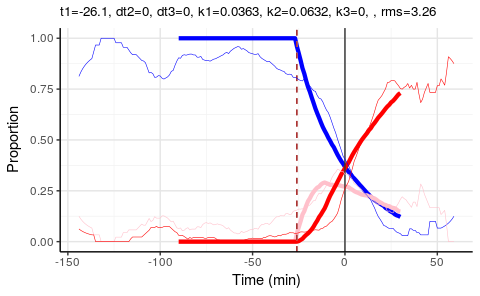

```r
pars <- c3pars()
free <- c("t1", "k1", "k2")
chr.scr <- cacheData("fit_scramble_n3000_t1_k1_k2", fitChr, echr.scr, pars, free, nsim=3000, ntry=16, ncores=8, binDir=binDir)
plotTimelines(chr.scr, expdata = echr.scr, withpars=TRUE)
```

## NCAPD2

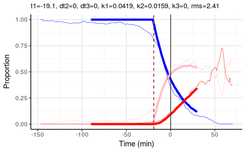

```r
pars <- chr.scr$pars
free <- c("t1", "k2")
chr.d2 <- cacheData("fit_NCAPD2_n3000_t1_k2", fitChr, echr.d2, pars, free, nsim=3000, ntry=16, ncores=8, binDir=binDir)
plotTimelines(chr.d2, expdata = echr.d2, withpars=TRUE)
```

And for comparison, NCAPD2 with $t_1$, $k_1$ and $k_2$ free.

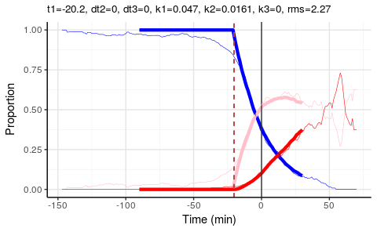

```r
pars <- chr.scr$pars
free <- c("t1", "k1", "k2")
chr.d2.f <- cacheData("fit_NCAPD2_n3000_t1_k1_k2", fitChr, echr.d2, pars, free, nsim=3000, ntry=16, ncores=8, binDir=binDir)
plotTimelines(chr.d2.f, expdata = echr.d2, withpars=TRUE)
```

# 3/08/2017

## NCAPD3

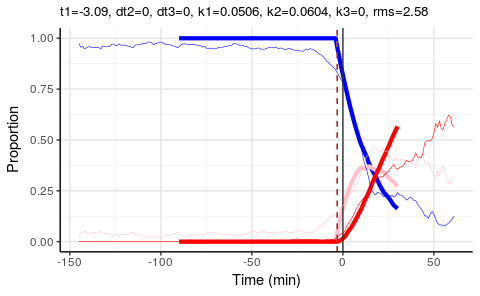

```r
pars <- chr.scr$pars
free <- c("t1", "k1")
chr.d3 <- cacheData("fit_NCAPD3_n3000_t1_k1", fitChr, echr.d3, pars, free, nsim=3000, ntry=16, ncores=8, binDir=binDir)
plotTimelines(chr.d3, expdata = echr.d3, withpars=TRUE)
```

And for comparison, NCAPD3 with $t_1$, $k_1$ and $k_2$ free.

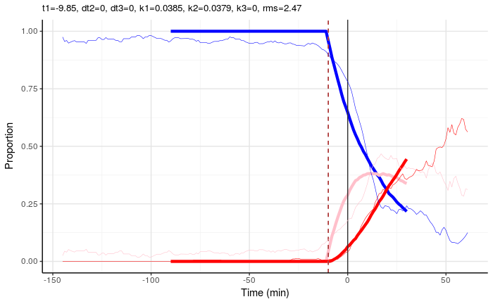

```r
pars <- chr.scr$pars
free <- c("t1", "k1", "k2")
chr.d3.f <- cacheData("fit_NCAPD3_n3000_t1_k1_k2", fitChr, echr.d3, pars, free, nsim=3000, ntry=16, ncores=8, binDir=binDir)
plotTimelines(chr.d3.f, expdata = echr.d3, withpars=TRUE)
```

## SMC2

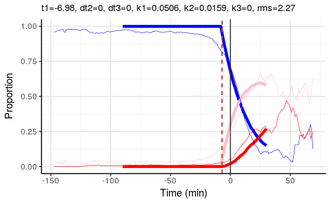

```r
pars <- chr.scr$pars
pars$k1 <- chr.d3$pars$k1
pars$k2 <- chr.d2$pars$k2
free <- c("t1")
chr.smc <- cacheData("fit_SMC2_n3000_t1", fitChr, echr.smc, pars, free, nsim=3000, ntry=16, ncores=8, binDir=binDir)
plotTimelines(chr.smc, expdata = echr.smc, withpars=TRUE)
```

And all free:

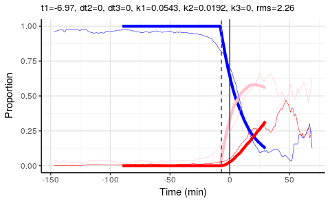

```r
pars <- chr.scr$pars
pars$k1 <- chr.d3$pars$k1
pars$k2 <- chr.d2$pars$k2
free <- c("t1", "k1", "k2")
chr.smc.f <- cacheData("fit_SMC2_n3000_t1_k1_k2", fitChr, echr.smc, pars, free, nsim=3000, ntry=16, ncores=8, binDir=binDir)
plotTimelines(chr.smc.f, expdata = echr.smc, withpars=TRUE)
```

# 04/08/2017

Models do not fit data well, mainly because at the start model predicts proportions of 0 and 1, while data are somewhere around 0.05 and 0.95. What if we squeeze the model towards the middle?

$$P_s = 0.5 + (P - 0.5)(1 - 2s)$$

where $s$ is a squeeze factor, $0 \leq s < 0.5$.

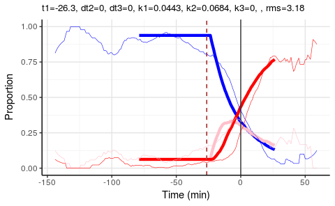

```r
pars <- c3pars()
pars$squeeze <- 0.05
free <- c("t1", "k1", "k2", "squeeze")
chr.scr.s <- cacheData("fit_scramble_n3000_t1_k1_k2_s", fitChr, echr.scr, pars, free, nsim=3000, ntry=16, ncores=8, binDir=binDir)
plotTimelines(chr.scr.s, expdata = echr.scr, withpars=TRUE)
```

Not very much different. Squeezing does not affect decay rates (fortunatelly!).

# 10/08/2017

E-mail from Tomo:

```
"How about asking Marek to fit the parameter values as follows (keep dt3=0, k3=0 for all):
1) Keep scramble as it is (and, separately, fit all k1, k2, t1 and dt2; dt2 does not need to be zero)
2) For NCAPD2, fix k1 and t1 (same as scramble), and fit k2 and dt2.
3) For NCAPD3, fix k2 and dt2 (same as scramble), and fit k1 and t1.
4) For SMC2, fix k1 and t1 from 3), fix k2 and dt2 from 2), and compare. Separately, fit all k1, k2, t1 and dt2.

If it is difficult to fit all 4 parameters in ‘separately’ plans in 1) and 4), no need to try it."
```

## Scramble

Fitting with $k_1$, $k_2$, $t_1$ and $\Delta t_2$ free.

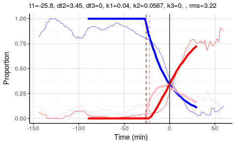

```r
pars <- c3pars()
free <- c("t1", "k1", "k2", "dt2")
chr.scr.dt2 <- cacheData("fit_scramble_n3000_t1_k1_k2_dt2", fitChr, echr.scr, pars, free, nsim=3000, ntry=32, ncores=6, binDir=binDir)
plotTimelines(chr.scr.dt2, expdata = echr.scr, withpars=TRUE)
```